# The Effectiveness of Marketing on Social Media

## Bar Graph for Interest Level of Ads for Each App

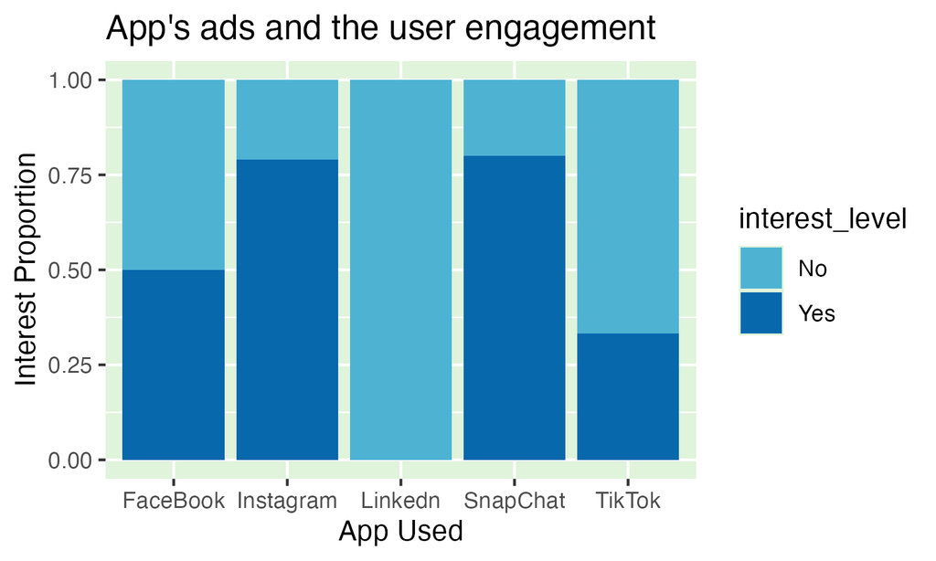

The graph shows each respective app and the interest level in each respective app. For FaceBook it appears that 50% of ads advertised on FaceBook are considered as interesting. Instagram and Snapchat also to appear to have favorable ads such that 78.9% of Instagram ads are deemed interesting which is relatively similar to Snapchat’s 80% ads being interesting. This heavily contrasts to TikTok’s 33.3% ads being liked as well as Linkedn ads being unfavorable(0% Linkedn ads are interesting). Indicative of TikTok’s ads being relatively uninteresting, and Linkedn’s ads being significantly uninteresting. This suggests that Instagram and Snapchat tend to display more engaging ads that attract the attention of users. Such that, these two apps have relatively high proportions of engaging ads, which is followed by FaceBook’s ads. Therefore, this provides an insight for companies and informs me of which app engages the audience more such that companies should look to promote ads on Instagram and Snapchat.

## Point Graph of Time Spent on each App

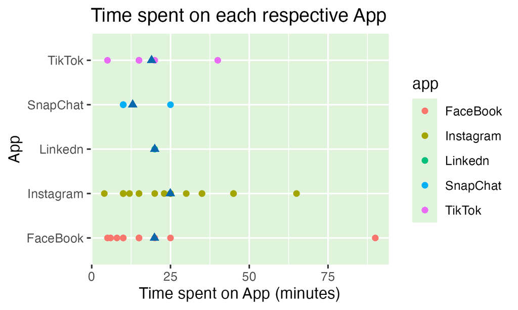

point graph to display the time spent on each app per session

The point graph shows the time spent on each app where each point represents a single session and the length of the session in minutes. The triangular pointer points to the mean value of the time spent on the app. It is evident on average Instagram is the social media app which I spend the longest on such that on average, Instagram tends to be longer spent on compared to the other apps. There appears to be a very large point in the FaceBook group indicating an outlier as it is significantly far from other values. This could suggest I was utilising FaceBook’s messaging function where I was messaging another user as opposed to usually searching and exploring FaceBook pages. Such that, the mean time spent on Instagram was 24.9 minutes, in comparison to Snapchat where the mean time spent was only 13 minutes. Hence indicating which apps users tend to stay longer on and help identify which apps users and myself usually spend longer on so that companies can identify which apps will give them greater and longer exposure for their ads.

## Density plot of ads viewed during daytime and evening-night

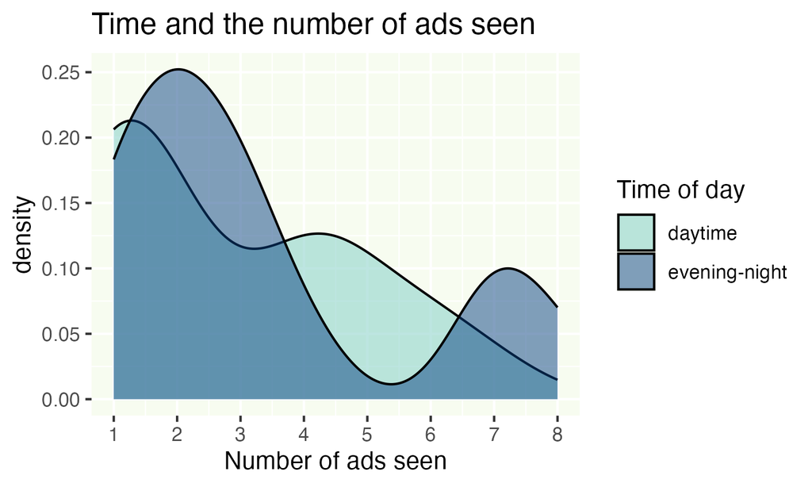

The density graph shows the number of ads typically seen in relation to daytime and evening-night, the two groups. Daytime is to be considered anytime before and inclusive of 6:00:00pm whereas the group evening-night is considered to be anytime after 6:00:00pm. Both time frame groups appear to have the highest proportion of the number of ads between 1 and 3. Suggesting that 1-3 ads is the most common range of ads seen for when social media was used before and at 6pm as well as after 6pm.This is evident as only 2 ads were seen during evening/night 25% of the time. Similar to daytime, only 1 ad was seen 21.25% of time during daytime. These are the highest proportions of the number of ads seen for each group respectively. Hence, regardless of the time of day, I tend to see 1-3 ads displayed by the peaks in the graph.

For when social media accessed during evening-night, there appears to be another second smaller peak for 7-8 ads seen, in reaching a small peak value of 10%. Hence, longer usage times at night could have potentially lead to more ads exposed to me. These instances where I was exposed to a greater number of ads could be when I am active on social media for a longer period of time before sleeping.

There also appears to be a slight dip for the evening-night group for when 5 to 6 ads were seen to indicate that it wasn’t frequent to see 5-6 ads during evening and night time.This may be due to chance or shorter sessions during the evening due to events such as dinner, completing assignments, or other commitments. Compared to the daytime, the proportion for 5-6 ads seen is higher than evening/night.

## Relationship between the time spent on each app and the number of ads seen

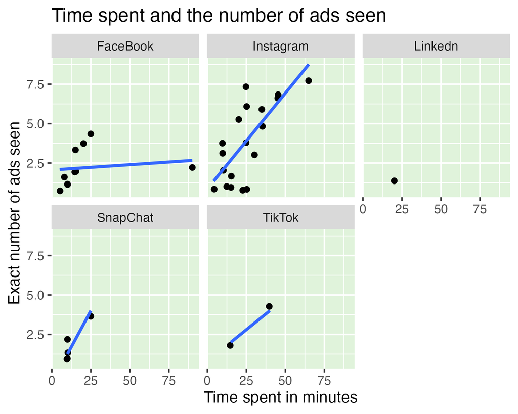

## Conclusion

I can conclude that I tend to utilise Instagram the most which is indicative as the most popular social media app used. This may be due to the fact that Instagram has multiple features such as reels- short videos, story view, and messaging functions which provides a variety of engaging features that retain users and my attention for longer. It is also evident that Instagram and Snapchat tend to display the most engaging ads which gives an insight to which social media app promotes the most interesting ads. Also it was concluded that the longer I spend on a social media app, the more ads I see. In particular, Instagram and Snapchat have a higher rate of ads seen which means that the more time I spend on these apps, the number of ads I see increases at a faster rate on these apps. Also regardless of the time of the day (before and upto 6pm and after 6pm), I tend to mostly see 1-3 ads, signified by having the highest proportion for each group respectively.